# Assignment 1 - The tidyverse

Henry Baker (henrycgbaker)

September 25, 2023 | 10:57:58 | CEST

```r
library(legislatoR)
library(tibble)
library(dplyr)
library(lubridate)
library(ggplot2)
library(stringr)
```

### Getting started with the Comparative Legislators Database

The Comparative Legislators Database (CLD) includes political, sociodemographic, career, online presence, public attention, and visual information for over 45,000 contemporary and historical politicians from ten countries (see the [corresponding article](https://www.cambridge.org/core/journals/british-journal-of-political-science/article/comparative-legislators-database/D28BB58A8B2C08C8593DB741F42C18B2) for more information). It can be accessed via `legislatoR` - an R package that is available on both [CRAN](https://cran.r-project.org/web/packages/legislatoR/index.html) and [GitHub](https://github.com/saschagobel/legislatoR).

Before you start with the following tasks, skim the tutorial to make yourself familiar with the database. You find it [here](https://cran.r-project.org/web/packages/legislatoR/vignettes/legislatoR.html).

For the following tasks, you will work with ONE of the legislatures. The legislature you’ll work with depends on your first name:

| Your first name starts with… | Legislature | Code |
| --- | --- | --- |
| A-C | Austrian Nationalrat | `aut` |
| D-F | Canadian House of Commons | `can` |
| G-I | Czech Poslanecka Snemovna | `cze` |
| J-L | Spanish Congreso de los Diputados | `esp` |
| M-O | French Assemblée | `fra` |
| P-R | German Bundestag | `deu` |
| S-U | Irish Dail | `irl` |
| V-X | UK House of Commons | `gbr` |
| Y-Z | US House of Representatives | `usa_house` |

The following tasks will be based on data from the `core` and `political` tables of the database.

```r
# get "Core" table for the Czech legislature
cze_core <- get_core(legislature = "cze")
glimpse(cze_core)
```

```
Rows: 1,124
Columns: 12
$ country    <chr> "CZE", "CZE", "CZE", "CZE", "CZE", "CZE", "CZE", "CZE", "CZ…
$ pageid     <chr> "1342947", "1491586", "1342483", "1394139", "63124", "53294…
$ wikidataid <chr> "Q44473433", "Q63225049", "Q44467466", "Q55174000", "Q12045…
$ wikititle  <chr> "Eva_Matyášová", "Iva_Kalátová", "Milan_Pour", "Monika_Červ…
$ name       <chr> " Eva   Matyášová ", " Iva   Kalátová ", " Milan   Pour ", …
$ sex        <chr> "female", "female", "male", "female", "male", "male", "male…
$ ethnicity  <chr> NA, NA, NA, NA, NA, "white", NA, NA, NA, NA, "white", "whit…
$ religion   <chr> NA, NA, NA, NA, NA, NA, NA, NA, NA, NA, NA, NA, NA, NA, NA,…
$ birth      <dttm> 1959-07-15, 1962-11-17, 1965-06-06, 1967-02-09, 1963-05-13…
$ death      <dttm> NA, NA, NA, NA, NA, NA, NA, NA, NA, NA, NA, NA, NA, NA, NA…
$ birthplace <chr> NA, NA, "49.91105,15.38978", NA, "50.0875,14.42139", "49.44…
$ deathplace <chr> NA, NA, NA, NA, NA, NA, NA, NA, NA, NA, NA, NA, NA, NA, NA,…
```

```r
# get "Political" table for the Czech legislature
cze_political <- get_political(legislature = "cze")
glimpse(cze_political)
```

```
Rows: 1,934
Columns: 7
$ pageid        <chr> "105983", "111966", "126314", "130214", "1356714", "1557…
$ session       <int> 1, 1, 1, 1, 1, 1, 1, 1, 1, 1, 1, 1, 1, 1, 1, 1, 1, 1, 1,…
$ party         <chr> "KDU-CSL", "CSSD", "ODS", "ODS", "ODS", "CSSD", "ODA", "…
$ constituency  <chr> "Jihomoravský", "Jihoèeský", "Severomoravský", "Støedoèe…
$ session_start <date> 1992-06-06, 1992-06-06, 1992-06-06, 1992-06-06, 1992-06…
$ session_end   <date> 1996-06-01, 1996-06-01, 1996-06-01, 1996-06-01, 1996-06…
$ service       <int> 1461, 1461, 1461, 1461, 1461, 1461, 1461, 1461, 1461, 14…
```

### Task 1 - Descriptives

1. What’s the overall share of female legislators in the entire dataset?

```r
female_count <- cze_core |>
  filter(sex == "female") |>
  nrow()

total_count <- nrow(cze_core)

female_share <- female_count / total_count
female_share # fema1e share of legislators in Czech Poslanecka Snemovna is 0.19
```

```
[1] 0.1948399
```

```r
round((female_share*100), 2)
```

```
[1] 19.48
```

fema1e share of legislators in Czech Poslanecka Snemovna is **19.48%**

2. How many (both in absolute and relative terms) legislators died in the same place they were born in?

Absolute:

```r
# absolute:
absolute_same <- cze_core |>
  filter(birthplace == deathplace) |>
  nrow()
absolute_same # 6 legislators died in the same place they were born
```

```
[1] 6
```

Relative:

```r
# relative:
total_dead_by_deathplace <- cze_core |>
  filter(!is.na(birthplace) & !is.na(deathplace)) |>
  nrow()
# this only includes those legislators who have both their birthplace and deathplace recorded in the analysis.

total_dead_by_dead <- cze_core |>
  filter(!is.na(death)) |>
  nrow()
# NB not all those recorded as dead have their 'deathplace' recorded.

# taking denominator for relative measure respectively as:
# 1)
relative_same_1 <- absolute_same / total_dead_by_deathplace
relative_same_1
```

```
[1] 0.4
```

```r
# 2)
relative_same_2 <- absolute_same / total_dead_by_dead
relative_same_2
```

```
[1] 0.125
```

Taking units for which there are values available for both birthplace and deathplace as the pool from which to construct a relative measure, **40%** of legislators died in the same place they were born (6/15).

*(If we were to take all the dead legislators as the pool then the answer would be 12.5% (6 / 48), however this is a less robust measure, as it may well be that the birth and deathplaces were in fact the same but one (or both) was not recorded for whatever reason)*

3. Create a new variable `age_at_death` that reports the age at which legislators died. Then, plot the distribution of that variable for the entire dataset.

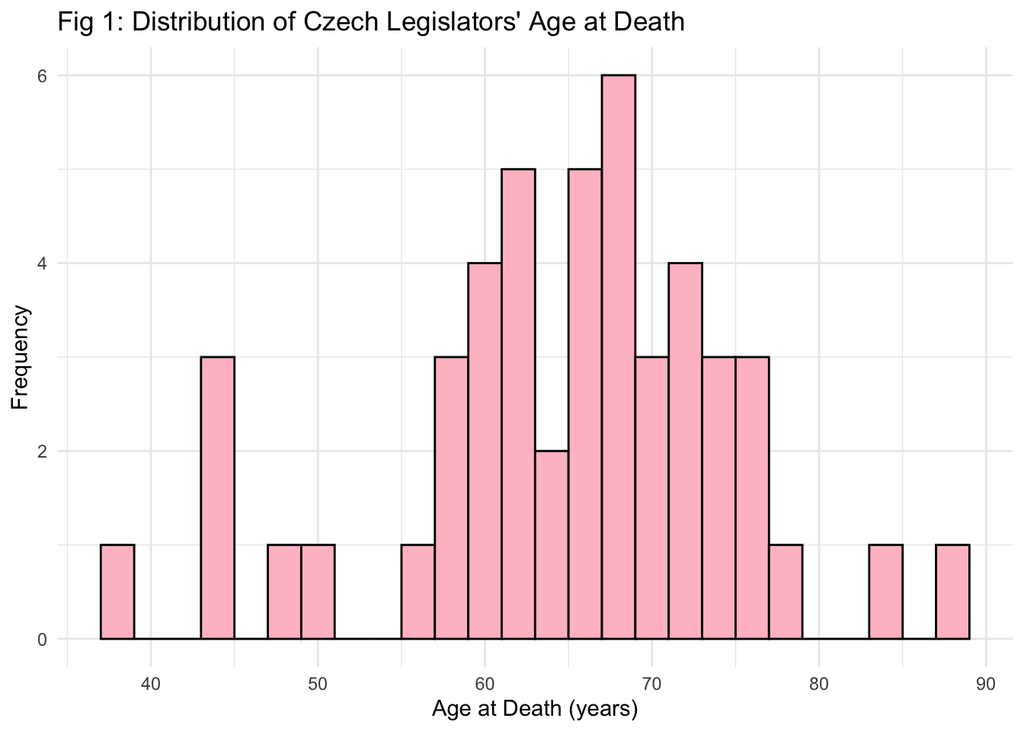

```r
# age at death variable, to nearest year
cze_core_2 <- cze_core |>
  filter(!is.na(birth) & !is.na(death)) |>
  mutate(
    age_at_death = (difftime(death, birth, units = "auto")/365.25)|>
      as.numeric() |>
      round(0)
  )

# plot a histogram, binwidth set to '2' as this gives reasonable granularity
fig1 <- ggplot(cze_core_2,
  aes(x = age_at_death)) +
  geom_histogram(binwidth = 2, fill = "pink", colour = "black") +
  theme_minimal() +
  labs(title = "Fig 1: Distribution of Czech Legislators' Age at Death",
       x = "Age at Death (years)",
       y = "Frequency") +
  theme_minimal()

fig1
```

4. What is the most frequent birthday in your sample (e.g., “January 15”)?

```r
cze_core_3 <- cze_core |>
  mutate(
    bday = format(birth, format = "%d-%m"))

bday_frequencies <- table(cze_core_3$bday) |>
  which.max() |>
  names()

bday_frequencies
```

```
[1] "01-01"
```

**January 1st**

While perfectly plausible, this seems perhaps too convenient and leads me to wonder if there were flaws within the data collection process - especially as summer birthdays are statistically more likely (in Europe). Perhaps 01 January was used as a placeholder if bday was unknown? I’ll examine the 2nd most frequent birthday in case.

```r
bday_frequency_2 <- table(cze_core_3$bday) |>
  sort(decreasing = T)

second_frequency_bday <- bday_frequency_2[2]|>
  names()
second_frequency_bday
```

```
[1] "01-10"
```

```r
# October 1st
```

If we were to discount 01-01, This might in fact be the truer value (given the possible data deficiencies here). Without more information it is not possible to make a concrete conclusion.

Still, as the most frequent value was 01-01, I’m also slightly suspicious of this value being the 1st of the month (again, perhaps if granular data on the exact day was unavailable for whatever reason (privacy?), the first of the month was used). For this reason, I’ll also take a quick look at the 3rd most frequent date.

```r
third_frequency_bday <- bday_frequency_2[3]|>
  names()
third_frequency_bday
```

```
[1] "05-12"
```

```r
# December 5th
```

While both the 2nd and 3rd most frequently appearing date are completely plausible, this 3rd entry is certainly not a placeholder. 01-01 is my answer given the data available, but it’s worth considering these other bday dates as well.

5. Generate a table that provides the 5 legislators with the longest names (in terms of number of characters, ignoring whitespace).

```r
cze_core_4 <- cze_core |>
  mutate(names_clean = gsub("-| ", "", name))|>
  mutate(char_length = nchar(names_clean)) |>
  arrange(desc(char_length))

longest_names <- cze_core_4 |>
  head(5) |>
  select(name, char_length)

# alternatively I could have used slice functions
cze_core_4 |>
  slice_max(char_length, n = 5) |>
  select(name, char_length)
```

| name | char_length |
| --- | --- |
| Zuzana Majerová Zahradníková | 26 |
| Jaroslava Pokorná Jermanová | 25 |
| Augustin Karel Andrle Sylor | 24 |
| Jana Mračková Vildumetzová | 24 |
| Zdenka Němečková Crkvenjaš | 24 |

### Task 2 - Exploring trends in the data

1. Using data from all sessions, provide a plot that shows the share of female legislators by session!

```r
cze_combo <- cze_political |>
  left_join(cze_core, by = "pageid")

cze_combo_reduced <- cze_combo |>
  select(-c(4, 5, 8:11, 14:18))

unique(cze_combo_reduced$session)
```

```
[1] 1 2 3 4 5 6 7 8 9
```

NB there have only been 9 sessions, this seems surprisingly few for a dataset going back to 1992…

```r
# NB there are 29 unique start dates...
length(unique(cze_combo$session_start))
```

```
[1] 29
```

```r
# NB there are 29 unique end dates...
length(unique(cze_combo$session_end))
```

```
[1] 29
```

…and there are 29 unique values for both start & end dates of the sessions. Worth checking if sessions is correctly coded.

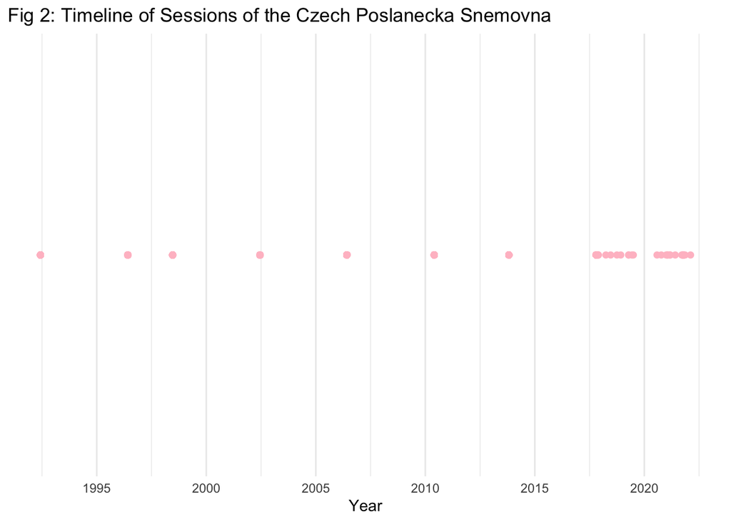

```r
# exploratory timeline to see when those dates fall; are they valid unique events?
fig2 <- ggplot(data = cze_combo, aes(x = session_start), label = Event) +
  geom_point(shape = 16, size = 2, color = "pink", y = 0.5) +
  labs(title = "Fig 2: Timeline of Sessions of the Czech Poslanecka Snemovna", x = "Year", y = NULL) +
  scale_x_date(date_breaks = "5 year", date_labels = "%Y") +
  theme_minimal()

fig2
```

This timeline shows that in fact the session variable is accurate, and that there have only been 9 unique sessions. The 29 unique values for the start/end date measure reflects a data collection issue for the final two sessions.

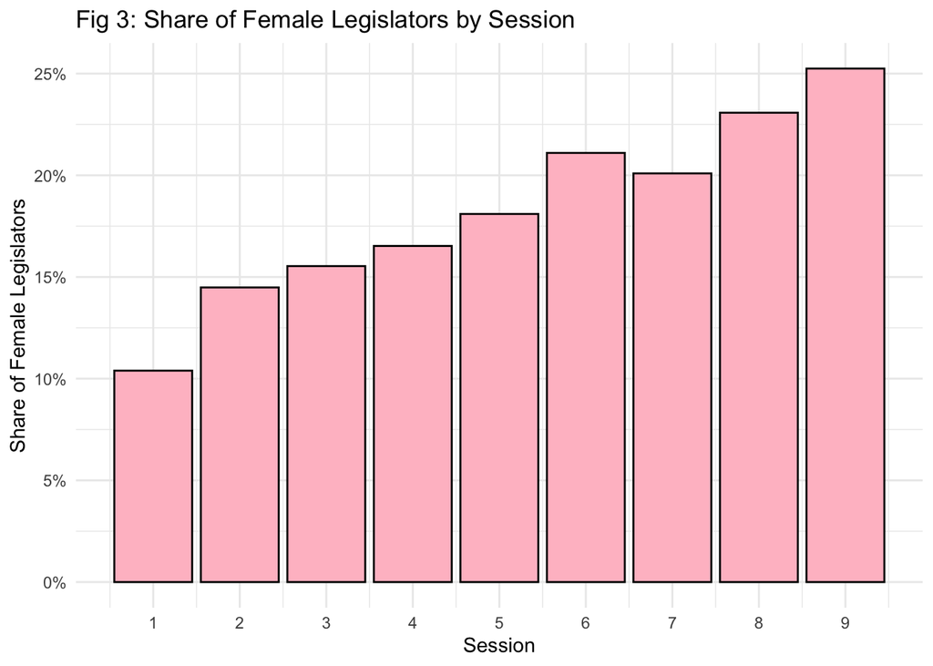

```r
share_female_2 <- cze_combo_reduced |>
  group_by(session)|>
  summarise(
    total_legis = n(),
    female_legis = sum(sex == "female", na.rm = TRUE),
    share_female = female_legis / total_legis
    )

fig3 <- ggplot(share_female_2, aes(x = session, y = share_female)) +
  geom_bar(stat = "identity", fill = "pink", colour = "black") +
  theme_minimal() +
  labs(title = "Fig 3: Share of Female Legislators by Session",
       x = "Session",
       y = "Share of Female Legislators") +
  scale_x_continuous(breaks = unique(share_female_2$session), labels = unique(share_female_2$session)) +
  scale_y_continuous(labels = scales::percent_format(scale = 100))

fig3
```

The share of female legislators has on average increased to almost 2.5 times its (admittedly low) baseline.

2. Explore another relation of variables in the dataset. Your analysis should (i) use data from both the `core` and the `political` table and (ii) feature data from several sessions. Also, offer a brief description and interpretation of your findings!

Let’s explore professions variable.

```r
# Unfortunately the 'Professions dataset doesn't contain much useful information to work with, so discarding.
cze_prof <- get_profession(legislature = "cze")

cze_combo_2 <- cze_core |>
  left_join(cze_political, by = "pageid") |>
  left_join(cze_prof, by = "wikidataid")
view(cze_combo_2)


cze_combo_3 <- cze_core |>
  left_join(cze_political, by = "pageid") # |>
  # select(- c(1:4), (-1:-3))
```

Let’s explore the ethnicity variable.

```r
# Unfortunately ethnicity variable also fails to provide analytical purchase as the only valid value is 'white'.
ethnicity_types <- unique(cze_combo_3$ethnicity)
ethnicity_types
```

```
[1] NA      "white"
```

Let’s explore the relationship between party and share of female legislators.

```r
unique_parties <- unique(cze_combo_3$party)

# the below custom function & for loop didn't work, but I want to come back and get it working (hopefully before submission)

# female_share_fn <- (df, party_name) {
  # df |>
  # group_by(session) |>
  # filter(party == party_name) |>
  # summarize(female_share = mean(sex == "female"))
# }

# female_share_fn <- function(df, party_name) {
  # df |>
    # filter(party == party_name) |>
    # group_by(session) |<
    # summarize(female_share = mean(sex == "female"))
# }

# female_share_fn(cze_combo_2, ANO)

# for (party_name in unique_parties) {
  # female_share_fn()
# }

###############################################################

# rank parties by the amount they appear throughout the dataset across all sessions; I did this because some parties appear and disappear according to session, so I want to stabilise the units I am examining.
parties_prop_ungrouped <- prop.table(table(cze_combo_3$party)) |>
  sort(decreasing = T)
parties_prop_ungrouped
```

```
         ODS         CSSD         KSCM          ANO      KDU-CSL       TOP 09
0.2564632885 0.2414684592 0.1199586350 0.0966907963 0.0718717684 0.0460186143
         SPD         STAN        BEZPP       US-DEU          ODA      SPR-RSC
0.0217166494 0.0191313340 0.0180972079 0.0165460186 0.0160289555 0.0160289555
      Piráti           VV        Úsvit      HSD-SMS          KDS          LSU
0.0134436401 0.0129265770 0.0072388831 0.0051706308 0.0051706308 0.0041365047
          SZ          ČSS          MNS          SLK          DSP          LES
0.0041365047 0.0025853154 0.0015511892 0.0015511892 0.0010341262 0.0005170631
     Nestran
0.0005170631
```

```r
# returns a vector of the 5 most 'influential' parties ('influential' understood as having persistent representation... this is of course a very contentious definition, but will do for the purpose of this analysis)
parties_to_include <- names(parties_prop_ungrouped[1:5])
parties_to_include
```

```
[1] "ODS"     "CSSD"    "KSCM"    "ANO"     "KDU-CSL"
```

```r
female_share_df <- cze_combo_3 |>
  filter (party %in% parties_to_include) |>
  group_by(session, party) |>
  summarize(female_share = mean(sex == "female"))
glimpse(female_share_df)
```

```
Rows: 36
Columns: 3
Groups: session [9]
$ session      <int> 1, 1, 1, 1, 2, 2, 2, 2, 3, 3, 3, 3, 4, 4, 4, 4, 5, 5, 5, …
$ party        <chr> "CSSD", "KDU-CSL", "KSCM", "ODS", "CSSD", "KDU-CSL", "KSC…
$ female_share <dbl> 0.12500000, 0.13333333, 0.16216216, NA, 0.18032787, 0.100…
```

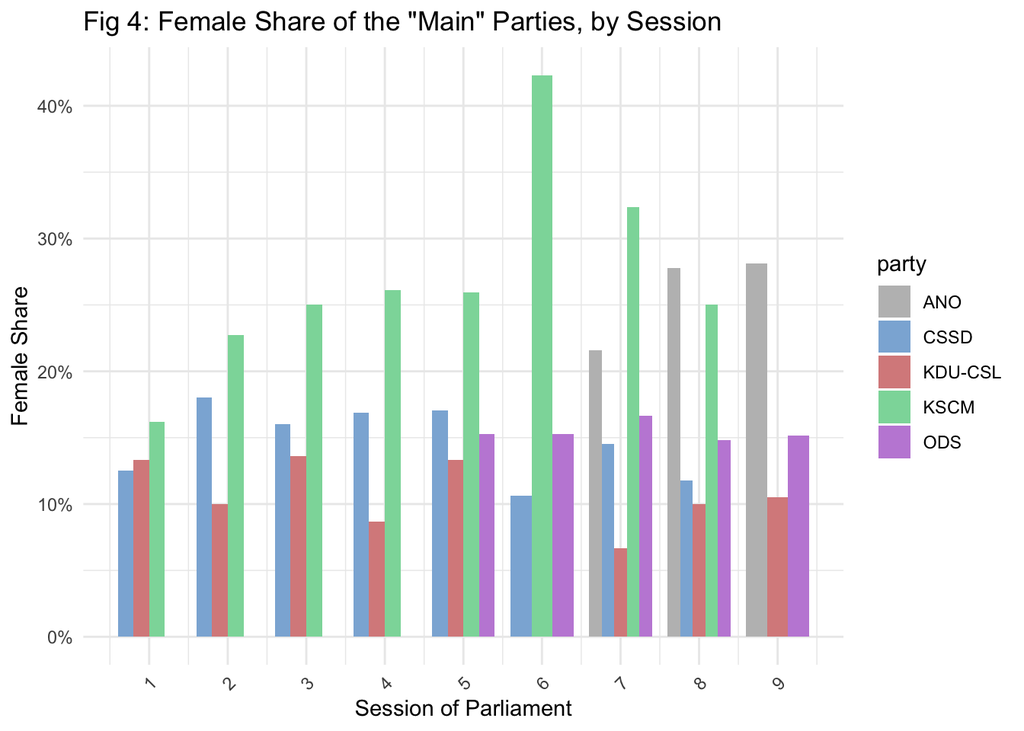

```r
# NAs in the female_share variable represent no female legislators, this is problematic for descriptive statistics
female_share_df <- female_share_df |>
  mutate(female_share = ifelse(is.na(female_share), 0, female_share))

# Create bar chart
plot4 <- ggplot(female_share_df, aes(x = session, y = female_share, fill = party)) +
  geom_bar(stat = "identity", position = "dodge", width = 0.8) +
  scale_fill_manual(values = c('CSSD' = '#8CB3D9', 'KDU-CSL' = '#D98C8C', 'KSCM' = '#8CD9A8', 'ODS' = '#C28CD9', 'ANO' = 'grey' )) +
  labs(x = 'Session of Parliament', y = 'Female Share',
       title = 'Fig 4: Female Share of the "Main" Parties, by Session') +
  theme_minimal() +
  theme(axis.text.x = element_text(angle = 45, hjust = 1)) +
  scale_x_continuous(breaks = unique(female_share_df$session), labels = unique(female_share_df$session)) +
  scale_y_continuous(labels = scales::percent_format(scale = 100))
plot4
```

The problem with this plot is that ANO and ODS both display an equivalent pattern, but for significantly different reasons. ANO only appears in the latter half because as a party ANO did not hold seats before session 7, and when it does debut, it did so with a (relatively) strong female share. ODS on the other hand does not appear in the graph before session 5, NOT because it didn’t have any legislators, but because it did not have any female legislators.

These are two different stories / mechanisms at work, but which are obscured and elided by the data presentation here. To overcome this, I will only plot parties that were ‘persistent’ - ie appeared relatively consistently between sessions 1 - 9.

Are there any truly persistent/consistent parties?

```r
# selecting only parties which are truly persistent
party_persistent <- cze_combo_3 |>
  group_by(party) |>
  summarize(unique_sessions = length(unique(session)))
party_persistent
```

| party | unique_sessions |
| --- | --- |
| ANO | 3 |
| BEZPP | 2 |
| CSSD | 8 |
| DSP | 1 |
| HSD-SMS | 1 |
| KDS | 1 |
| KDU-CSL | 8 |
| KSCM | 8 |
| LES | 1 |
| LSU | 1 |

[output cut: 15 more lines]

```r
party_persistent <- party_persistent |>
  mutate(consistent = (unique_sessions == 9))

print(party_persistent$consistent)
```

```
 [1] FALSE FALSE FALSE FALSE FALSE FALSE FALSE FALSE FALSE FALSE FALSE FALSE
[13] FALSE  TRUE FALSE FALSE FALSE FALSE FALSE FALSE FALSE FALSE FALSE FALSE
[25] FALSE
```

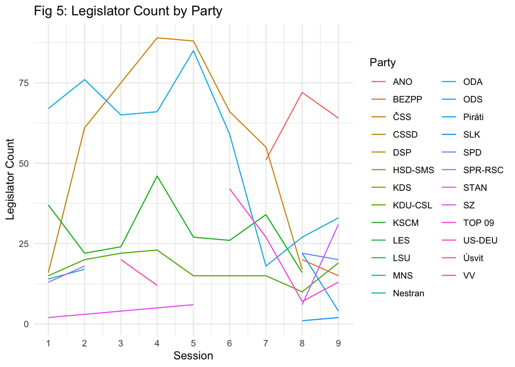

```r
party_share_legis <- cze_combo_3 |>
  group_by(session, party) |>
  summarize(legis_count = n())

plot5 <- ggplot(party_share_legis, aes(x = session, y = legis_count, color = party)) +
  geom_line() +
  labs(x = "Session", y = "Legislator Count", title = "Fig 5: Legislator Count by Party") +
  theme_minimal() +
  scale_color_discrete(name = "Party") +
  scale_x_continuous(breaks = 1:max(party_share_legis$session))
plot5
```

Honestly this is a mess in term of data presentation, but the important takeaway is that it presents a deeply fragmented and highly dynamic system of political parties. I had based my research direction on assumptions grounded in familiarity with the UK / US / W.EU political chambers which can be characterised as displaying less dynamism, and are more apt for longitudinal analysis along main party lines.

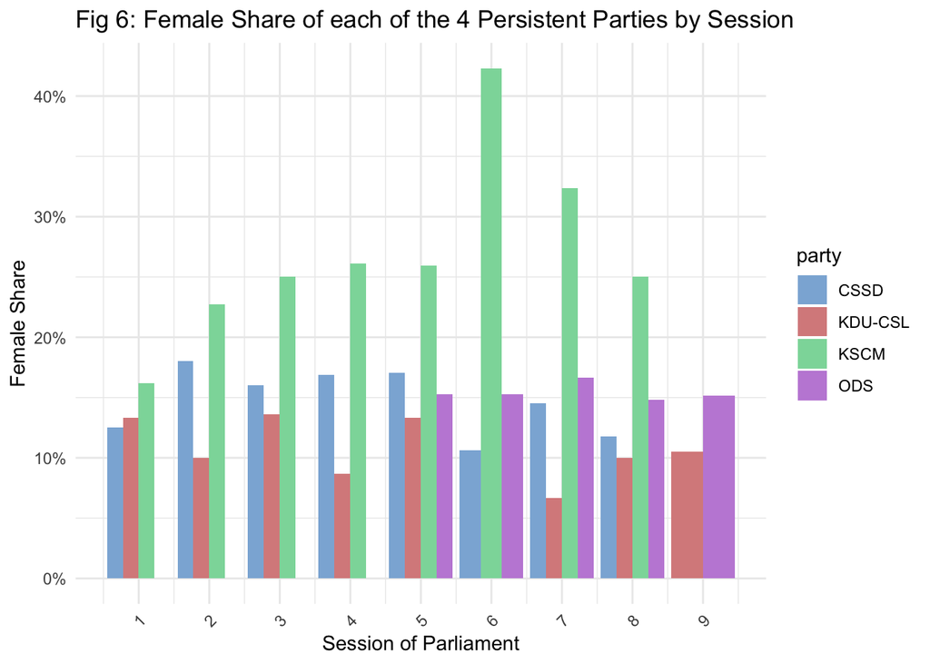

```r
parties_to_include_2 <- party_persistent |>
                                filter(unique_sessions >= 5) |>
                                         pull(party)
female_share_df_2 <- female_share_df |>
  filter(party %in% parties_to_include_2)


plot6 <- ggplot(female_share_df_2, aes(x = session, y = female_share, fill = party)) +
  geom_bar(stat = "identity", position = "dodge") +
  scale_fill_manual(values = c('CSSD' = '#8CB3D9', 'KDU-CSL' = '#D98C8C', 'KSCM' = '#8CD9A8', 'ODS' = '#C28CD9')) +
  labs(x = 'Session of Parliament', y = 'Female Share',
       title = 'Fig 6: Female Share of each of the 4 Persistent Parties by Session') +
  theme_minimal() +
  theme(axis.text.x = element_text(angle = 45, hjust = 1)) +
  scale_x_continuous(breaks = unique(female_share_df$session), labels = unique(female_share_df$session)) +
  scale_y_continuous(labels = scales::percent_format(scale = 100))
plot6
```

As expected, this looks very similar to the previous plot minus ANO. Still it is now somewhat more consistent in isolating and presenting the change in female share of legislators conditioning on a degree of party perserverance.

I will leave this as my final analysis, but its limitations should be noted. 1) This now simply ignores the ANO party, which if we look at the data has recently become a major player in the legislature. 2) It’s also the case that none of the parties exhibit perfect perseverance, and so when each of them fails to show up in a session it is important not to interprete this as a lack of female legislators for that party for that session, but a lack of overall party presence for that session. In fact, in this sense, it would be better just to look at female share of the legislature as a whole, not conditioning on party given some of the misleading tendenceis of the above.

Nevertheless, it is best to treat Figure 6 as a complement to Figure 3 which gives a more accurate overall impression of the phenomenon and use Figure 6 to supplement that understanding with a more granular party-based understanding. With that in mind we can say that there isn’t a dramatic change in female representation amongst the most persistent parties, and so the trend seen in Figure 3 must by inference be driven by external parties. Ultimately there’s not enough data points and too much variance for this to be statistically significant.